# Data Ants

Alejandro Pinto

2024-10-25

## DATA ANTS

Para iniciar con el modelo de regresión generalizado, se inicia con la data *ants* de la librería:

```r
library(GLMsData)
data(ants)
head(ants)
```

```
##   Site Srich Habitat Latitude Elevation
## 1  TPB     6  Forest    41.97       389
## 2  HBC    16  Forest    42.00         8
## 3  CKB    18  Forest    42.03       152
## 4  SKP    17  Forest    42.05         1
## 5   CB     9  Forest    42.05       210
## 6   RP    15  Forest    42.17        78
```

Si revisamos las columnas y sus datos tenemos que:

```r
table(ants$Habitat)
```

```
##
##    Bog Forest
##     22     22
```

Observamos que la primera columna es’*Site*’, una abreviaciòn del nombre del sitio. La segunda columna es ‘*Srich*’, donde hace referencia a la riqueza en especies de hormigas. Luego està ‘*Habitat*’ donde podemos encotrar dos tipos de habitat: ‘*Bog*’ y ‘*Forest*’. La siguiente columna se ‘*Latitude*’, la cual representa la latitud del sitio. Y por ultimo, tenemos la columna ‘*Elevation*’, donde muestra la elevacion del sitio en metros sobre nivel del mar.

Para poder realizar el modelo lineal generalizado, necesitamos cambiar las variables categóricas a variables dummies:

```r
ants$Habitat=ifelse(ants$Habitat=="Forest",1,0)

ants
```

```
##    Site Srich Habitat Latitude Elevation
## 1   TPB     6       1    41.97       389
## 2   HBC    16       1    42.00         8
## 3   CKB    18       1    42.03       152
## 4   SKP    17       1    42.05         1
## 5    CB     9       1    42.05       210
## 6    RP    15       1    42.17        78
## 7    PK     7       1    42.19        47
## 8    OB    12       1    42.23       491
## 9   SWR    14       1    42.27       121
## 10  ARC     9       1    42.31        95
## 11   BH    10       1    42.56       274
## 12   QP    10       1    42.57       335
## 13  HAW     4       1    42.58       543
## 14  WIN     5       1    42.69       323
```

[output cut: 30 more lines]

```r
modelAnts = glm(Srich~Latitude+Elevation+Habitat,data=ants,family="poisson")
```

**A.** Estime el mejor modelo de regresion para determinar el numero de hormigas que pueden habitar un bosque:

Para esto recurrimos a la prueba de Akaike (AIC):

```r
step(modelAnts)
```

```
## Start:  AIC=209.04
## Srich ~ Latitude + Elevation + Habitat
##
##             Df Deviance    AIC
## <none>           40.690 209.04
## - Elevation  1   50.284 216.64
## - Latitude   1   56.649 223.00
## - Habitat    1   70.376 236.73
```

```
##
## Call:  glm(formula = Srich ~ Latitude + Elevation + Habitat, family = "poisson",
##     data = ants)
##
## Coefficients:
## (Intercept)     Latitude    Elevation      Habitat
##   11.936812    -0.235793    -0.001141     0.635439
##
## Degrees of Freedom: 43 Total (i.e. Null);  40 Residual
## Null Deviance:       102.8
## Residual Deviance: 40.69     AIC: 209
```

Como se puede observar, las variables *Elevation*, *Latitude* y *Habitat* explican bien el numero de hormigas que pueden haber en el bosque, con un valor *AIC* de **209.04**.

Si observamos las bondades de ajuste, empezando por el PseudoR2:

```r
library(DescTools)
PseudoR2(modelAnts, "Nagelkerke")
```

```
## Nagelkerke
##  0.7579558
```

Dado que es mayor a **0.4**, existe una excelente explicacion del la latitud, elevacion y habitat respecto al numero de hormigas en Estados Unidos. Pasando a la prueba de Deviance:

```r
summary(modelAnts)
```

```
##
## Call:
## glm(formula = Srich ~ Latitude + Elevation + Habitat, family = "poisson",
##     data = ants)
##
## Coefficients:
##               Estimate Std. Error z value Pr(>|z|)
## (Intercept) 11.9368121  2.6214970   4.553 5.28e-06 ***
## Latitude    -0.2357930  0.0616638  -3.824 0.000131 ***
## Elevation   -0.0011411  0.0003749  -3.044 0.002337 **
## Habitat      0.6354389  0.1195664   5.315 1.07e-07 ***
## ---
## Signif. codes:  0 '***' 0.001 '**' 0.01 '*' 0.05 '.' 0.1 ' ' 1
##
## (Dispersion parameter for poisson family taken to be 1)
##
##     Null deviance: 102.76  on 43  degrees of freedom
## Residual deviance:  40.69  on 40  degrees of freedom
## AIC: 209.04
##
## Number of Fisher Scoring iterations: 4
```

Realizamos la diferencia obn Chi2 en base a los datos de ‘Null Deviance’ y ‘Residual Deviance’:

```r
1-pchisq(102.76-40.69,43-40)
```

```
## [1] 2.122746e-13
```

```r
summary(modelAnts)
```

```
##
## Call:
## glm(formula = Srich ~ Latitude + Elevation + Habitat, family = "poisson",
##     data = ants)
##
## Coefficients:
##               Estimate Std. Error z value Pr(>|z|)
## (Intercept) 11.9368121  2.6214970   4.553 5.28e-06 ***
## Latitude    -0.2357930  0.0616638  -3.824 0.000131 ***
## Elevation   -0.0011411  0.0003749  -3.044 0.002337 **
## Habitat      0.6354389  0.1195664   5.315 1.07e-07 ***
## ---
## Signif. codes:  0 '***' 0.001 '**' 0.01 '*' 0.05 '.' 0.1 ' ' 1
##
## (Dispersion parameter for poisson family taken to be 1)
##
##     Null deviance: 102.76  on 43  degrees of freedom
## Residual deviance:  40.69  on 40  degrees of freedom
## AIC: 209.04
##
## Number of Fisher Scoring iterations: 4
```

Como los valores de PR(>|z|) son menor a 0.05, se rechaza ho. Es decir, existe evidencia estadística de que la elevacion, latitud y habitat del sitio influyen sobre el numero de hormigas en Estados Unidos.

**B.** Datos atipicos e influyentes:

En el caso del modelo lineal generalizado, podemos revisar los datos atipicos residuales de Deviance y Pearson y comparamos sus resultados. Si graficamos los residuos:

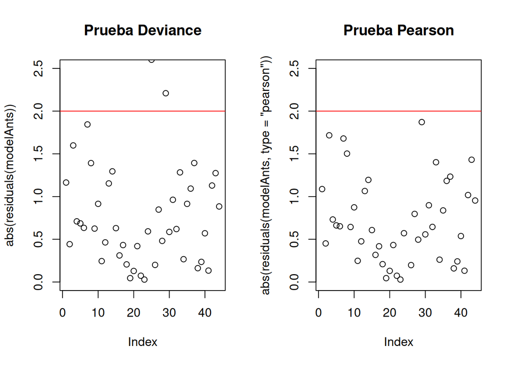

```r
par(mfrow=c(1,2))
plot(abs(residuals(modelAnts)),ylim = c(0,2.5), main = "Prueba Deviance")
abline(h=2,col="red")

plot(abs(residuals(modelAnts, type="pearson")),ylim = c(0,2.5), main= "Prueba Pearson")
abline(h=2,col="red")
```

```r
atipicos=data.frame(deviance=abs(residuals(modelAnts)), pearson=abs(residuals(modelAnts,type="pearson")))
atipicos[atipicos$deviance>2 & atipicos$pearson>2,]
```

```
##    deviance  pearson
## 25 2.601471 3.017515
```

La tabla anterior nos muestra los datos mayores a *2* para la prueba Deviance y la prueba Pearson. Es decir, hay 1 dato que se considera dato atìpico, el cual es el dato *25*. Se debe revisar con el mirmecòlogo para revisar es dato.

Pasando a los datos influyentes, podemos revisar los StudResd, Hat-values y la distancia de Cook:

```r
library(car)
```

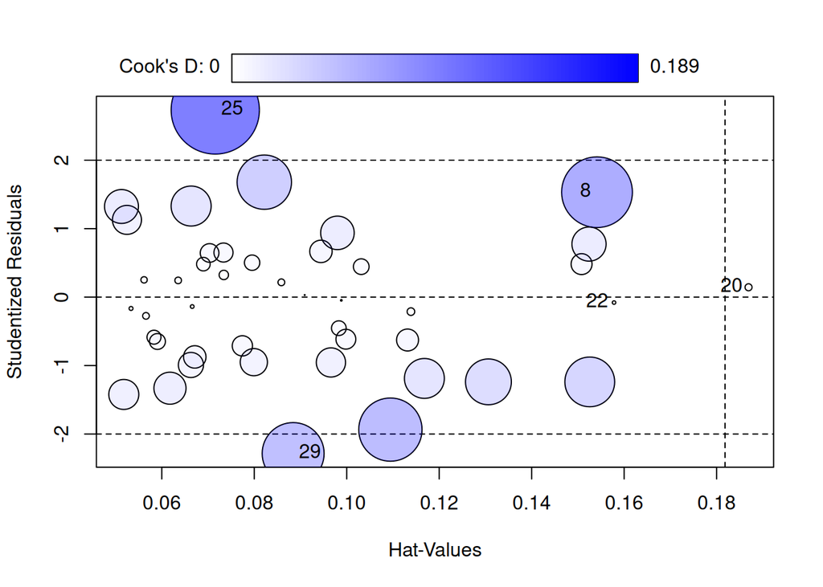

```
##        StudRes        Hat        CookD
## 8   1.53218493 0.15413184 0.1216127504
## 20  0.14340499 0.18690322 0.0011967172
## 22 -0.07996094 0.15781447 0.0002970387
## 25  2.73303272 0.07156127 0.1889777111
## 29 -2.28496233 0.08840726 0.0931469060
```

```r
par(mfrow=c(1,1))
influencePlot(modelAnts)
```

Se observan 5 posibles datos influyentes: *8*, *20*, *22*, *25* y *29*. Si analizamos La distancia de Cook, todos los datos quedan excluidos de los posibles datos influyentes, debido a que son menores a 1.

```r
coef(modelAnts)
```

```
##  (Intercept)     Latitude    Elevation      Habitat
## 11.936812111 -0.235793020 -0.001141079  0.635438863
```

Observamos que *‘Latitude’* y *‘Elevation’* tienen una asociacion negativa, mientras que *‘Habitat’* tiene una asociacion positiva. Verificando los exponenciales de cada uno:

```r
Lat = 1/exp(-0.235793020)
Ele = 1/exp(-0.001141079)
Lat
```

```
## [1] 1.265912
```

```r
Ele
```

```
## [1] 1.001142
```

Por cada Latitud adicional en el sitio de estudio, la oportunidad de encontrar hormigas disminuye 1.26. Por cada elevacion adicional en el sitio de estudio, la oportunidad de encontrar hormigas disminuye 1.001.